# Biostat 200C Homework 4

Due May 23 @ 11:59PM

Published

May 23, 2025

```r
library(faraway)
library(MASS)
library(ggplot2)
library(tidyverse)
library(mice)
library(MASS)
library(sandwich)
library(lmtest)
library(robustbase)
library(VGAM)
```

## 1 Q1. ELMR Excercise 7.5 (p150)

The debt data arise from a large postal survey on the psychology of debt. The frequency of credit card use is a three-level factor ranging from never, through occasionally to regularly.

```r
data(debt)
View(debt)
```

1. Declare the response as an ordered factor and make a plot showing the relationship to prodebt. Comment on the plot. Use a table or plot to display the relationship between the response and the income group.

**Solution**

1. Plot showcasing the relationship between credit card usage and pro-debt attitudes: The boxplot below illustrates how pro-debt attitudes (measured on a scale where higher values indicate a more favorable view of debt) vary according to credit card use frequency: never, occasionally, and regularly. There is a positive trend between the frequency of credit card use and pro-debt attitudes. Specifically, individuals who have never used credit cards tend to have lower pro-debt scores, with a median around 3. Those who occasionally use credit cards show a slight increase in the median pro-debt attitude, suggesting a more accepting view of debt. Finally, individuals who are regular credit card users have the highest median pro-debt score, indicating a stronger acceptance of debt. The spread of values is fairly consistent across groups, though outliers are more evident among those who use credit cards less frequently. Overall, the plot suggests that more frequent credit card users tend to have a more pro-debt mindset.

```r
debt$ccarduse <- factor(debt$ccarduse,
                            levels = c(1, 2, 3),
                            labels = c("never", "occasionally", "regularly"),
                            ordered = TRUE)
```

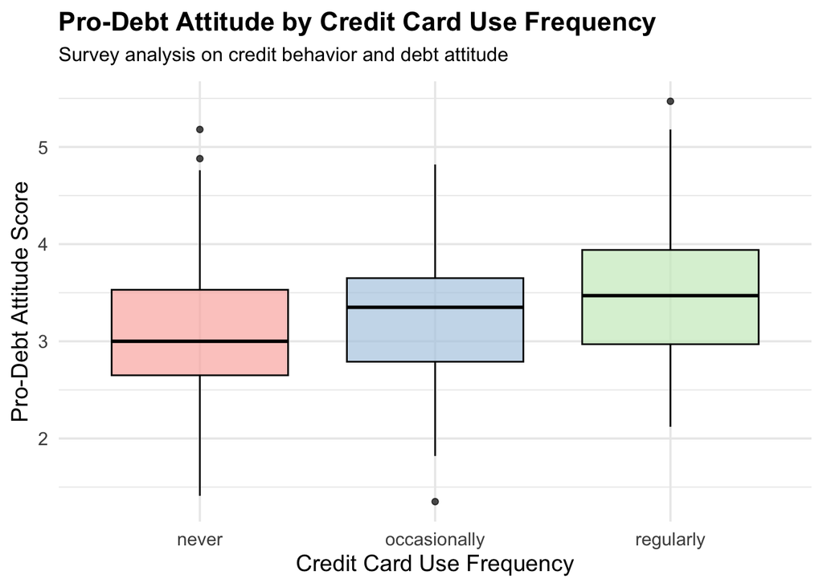

```r
filtered_data <- debt %>%
  filter(!is.na(ccarduse), !is.na(prodebt))

ggplot(filtered_data, aes(x = ccarduse, y = prodebt, fill = ccarduse)) +
  geom_boxplot(alpha = 0.7, color = "black") +
  scale_fill_brewer(palette = "Pastel1") +
  labs(
    title = "Pro-Debt Attitude by Credit Card Use Frequency",
    subtitle = "Survey analysis on credit behavior and debt attitude",
    x = "Credit Card Use Frequency",
    y = "Pro-Debt Attitude Score",
    fill = "Credit Card Use"
  ) +
  theme_minimal(base_size = 14) +
  theme(
    plot.title = element_text(face = "bold", size = 16),
    plot.subtitle = element_text(size = 12, margin = margin(b = 10)),
    legend.position = "none"
  )
```

```r
filtered_data <- subset(debt, !is.na(ccarduse) & !is.na(incomegp))
table(filtered_data$ccarduse, filtered_data$incomegp)
```

```
                1  2  3  4  5
  never        64 60 46 24 26
  occasionally 10 27 18 21 25
  regularly     4 13 18 20 38
```

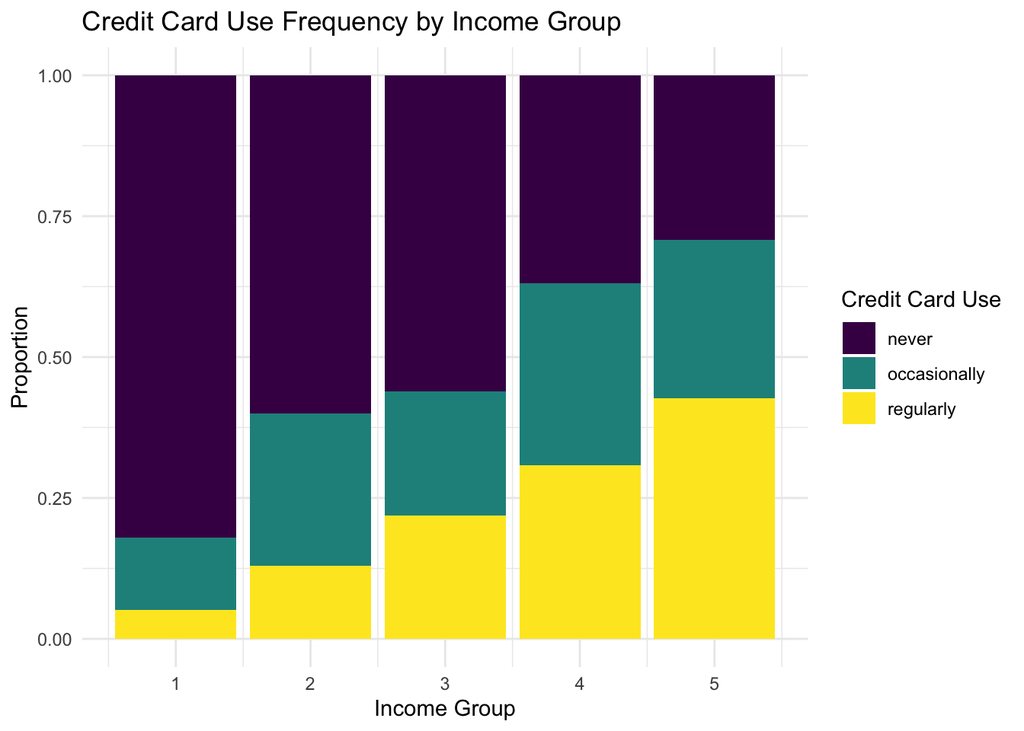

```r
ggplot(filtered_data, aes(x = incomegp, fill = ccarduse)) +
  geom_bar(position = "fill") +
  labs(title = "Credit Card Use Frequency by Income Group",
       x = "Income Group",
       y = "Proportion",
       fill = "Credit Card Use") +
  theme_minimal()
```

2. Fit a proportional odds model for credit card use with all the other variables as predictors. What are the two most significant predictors (largest t-values) and what is their qualitative effect on the response? What is the least significant predictor?

**Solution** The two most significant predictors (based on the largest t-values) are incomegp (t-value of 4.44) and bankacc (t-value of 3.55).

Interpretation for incomegp: Income group is a highly significant predictor of credit card use frequency. The odds of moving from “never” to “occasionally,” or from “never/occasionally” to “regularly” using a credit card increase by a factor of exp(0.47) ≈ 1.6 for each additional increase in income group level.

Interpretation for bankacc: Having a bank account is another strong predictor of credit card use frequency. The odds of moving from “never” to “occasionally,” or from “never/occasionally” to “regularly” using a credit card increase by a factor of exp(2.102) ≈ 8.18 for individuals who have a bank account compared to those who do not.

The least significant predictor is house (t-value of 0.499225). Whether or not an individual owns a house does not meaningfully differentiate their likelihood of using a credit card. If we were to interpret the coefficient for this predictor, it would suggest that the odds of moving from “never” to “occasionally,” or from “never/occasionally” to “regularly” using a credit card increase by a factor of approximately 1.122 (exp(0.116) for individuals who own a house compared to those who do not. However, given the low t-value, this effect is not statistically significant.

```r
model <- polr(ccarduse ~ ., data = debt, Hess = TRUE, na.action = na.omit)
coef_summary <- coef(summary(model))

predictor_summary <- coef_summary[!grepl("/", rownames(coef_summary)), ]
t_values <- predictor_summary[, "t value"]
p_values <- pnorm(abs(t_values), lower.tail = FALSE) * 2

results <- data.frame(
  Predictor = rownames(predictor_summary),
  Coefficient = predictor_summary[, "Value"],
  Std_Error = predictor_summary[, "Std. Error"],
  t_value = t_values,
  p_value = p_values
) |>
  arrange(desc(abs(t_value)))
results
```

```
                                    Predictor Coefficient Std_Error    t_value
occasionally|regularly occasionally|regularly  9.39436162 1.5051080  6.2416528
never|occasionally         never|occasionally  7.96937466 1.4751712  5.4023387
incomegp                             incomegp  0.47131302 0.1060967  4.4422966
bankacc                               bankacc  2.10269577 0.5933919  3.5435195
prodebt                               prodebt  0.61046374 0.1822466  3.3496578
cigbuy                                 cigbuy -0.73545858 0.2980681 -2.4674176
bsocacc                               bsocacc  0.47321630 0.2671329  1.7714642
singpar                               singpar  0.88171828 0.5971141  1.4766329
agegp                                   agegp  0.20568368 0.1576103  1.3050145
xmasbuy                               xmasbuy  0.47014289 0.4129631  1.1384621
manage                                 manage  0.18179169 0.1652903  1.0998331
locintrn                             locintrn  0.11881236 0.1423980  0.8343684
children                             children -0.07872411 0.1250325 -0.6296291
house                                   house  0.11600148 0.2323631  0.4992251
                            p_value
occasionally|regularly 4.329712e-10
never|occasionally     6.577759e-08
incomegp               8.900374e-06
bankacc                3.948241e-04
prodebt                8.091144e-04
cigbuy                 1.360916e-02
bsocacc                7.648353e-02
singpar                1.397741e-01
agegp                  1.918879e-01
xmasbuy                2.549276e-01
manage                 2.714049e-01
locintrn               4.040734e-01
children               5.289373e-01
house                  6.176208e-01
```

3. Fit a proportional odds model using only the least significant predictor from the previous model. What is the significance of this predictor in this small model? Are the conclusions regarding this predictor contradictory for the two models?

**Solution**

Below, we fit a proportional odds model using only the least significant predictor (house) from the previous model. In the full model, the house predictor is not statistically significant (p-value = 0.6176), suggesting no meaningful contribution to the frequency of credit card usage when other predictors are included. In the reduced model, however, house becomes highly significant (p-value = 0.0001), with a much larger coefficient of 0.558 and a t-value of 3.8951. This implies that when house is considered in isolation, it appears to have a strong relationship with credit card use frequency.

Interpretation of the coefficient: The odds of moving from “never” to “occasionally,” or from “never/occasionally” to “regularly” using a credit card increase by a factor of exp(0.558) ≈ 1.747 for individuals who own a house compared to those who do not.

```r
full_model <- polr(ccarduse ~ ., data = debt, Hess = TRUE, na.action = na.omit)
reduced_model <- polr(ccarduse ~ house, data = debt, Hess = TRUE, na.action = na.omit)

extract_house_stats <- function(model) {
  sumry <- coef(summary(model))
  house_row <- sumry[rownames(sumry) == "house", ]
  t_val <- house_row["t value"]
  p_val <- pnorm(abs(t_val), lower.tail = FALSE) * 2
  data.frame(
    Coefficient = house_row["Value"],
    Std_Error = house_row["Std. Error"],
    t_value = t_val,
    p_value = p_val
  )
}

comparison_table <- rbind(
  data.frame(Model = "Full Model", extract_house_stats(full_model)),
  data.frame(Model = "Reduced Model", extract_house_stats(reduced_model))
)

knitr::kable(comparison_table, digits = 4,
             caption = "Comparison of 'house' Predictor in Full vs. Reduced Models")
```

Comparison of ‘house’ Predictor in Full vs. Reduced Models

|  | Model | Coefficient | Std_Error | t_value | p_value |
| --- | --- | --- | --- | --- | --- |
| Value | Full Model | 0.116 | 0.2324 | 0.4992 | 0.6176 |
| Value1 | Reduced Model | 0.558 | 0.1433 | 3.8951 | 0.0001 |

4. Use stepwise AIC to select a smaller model than the full set of predictors. You will need to handle the missing values carefully. Report on the qualitative effect of the predictors in your chosen model. Can we conclude that the predictors that were dropped from the model have no relation to the response?

1. bankacc: (coefficient 1.7334). The odds of moving from “never” to “occasionally,” or from “never/occasionally” to “regularly” using a credit card increase by a factor of 5.659 (exp 1.7334) for individuals who have a bank account versus those who do not.
2. incomegp: (coefficient 0.4076). The odds of moving from “never” to “occasionally,” or from “never/occasionally” to “regularly” using a credit card increase by a factor of 1.5032 (exp 0.4076) for each increase in level of income group (by one unit)
3. cigbuy: (coefficient -0.6005). The odds of moving from “never” to “occasionally,” or from “never/occasionally” to “regularly” using a credit card decrease by a factor of 0.548 (exp -0.6005) for individuals who buy cigarattes versus those who do not.

4. bsocacc (coefficient 0.3155): The odds of moving from “never” to “occasionally,” or from “never/occasionally” to “regularly” using a credit card increases by a factor of 1.37 (exp 0.3155) for individuals who have a building society account versus those who do not.
5. manage (coefficient 0.2820): The odds of moving from “never” to “occasionally,” or from “never/occasionally” to “regularly” using a credit card increases by a factor of 1.325 (exp 0.2820) for each increase in rating of money management skill (one unit increase)
6. agegp (coefficient 0.1875): The odds of moving from “never” to “occasionally,” or from “never/occasionally” to “regularly” using a credit card increase by a factor of approximately 1.20 (exp 0.1875) for every increase in age group (one unit increase)
7. xmasbuy (coefficient 0.5257): The odds of moving from “never” to “occasionally,” or from “never/occasionally” to “regularly” using a credit card increase by a factor of approximately 1.692 (exp 0.5257) for individuals who buy Christmas presents for children versus those who do not.
8. prodebt (coefficient: 0.6014): The odds of moving from “never” to “occasionally,” or from “never/occasionally” to “regularly” using a credit card increase by a factor of approximately 1.825 (exp 0.6014) for a one unit increase in pro-debt attitude score.

No, we cannot conclude that the predictors dropped from the model have no relationship to the response. One reason is that stepwise AIC selection prioritizes predictive utility, not true causal or independent relationships. A predictor may have been dropped because its effect was redundant (collinear with retained predictors), its effect was small but nonzero, or missing data patterns reduced its apparent importance. In addition, imputation uncertainty—despite being handled appropriately—can reduce power to detect weak effects. Finally, a predictor with a small but nonzero effect might have been dropped, even though such effects could be meaningful in real-world contexts.

Other Comments: The final model has a AIC score of 810.7146 and a residual deviance of 790.7146.

```r
imputed_data <- mice(debt, m = 5, maxit = 50, method = "pmm", seed = 123, printFlag = FALSE)
complete_data <- complete(imputed_data, 1)
complete_data$ccarduse <- factor(complete_data$ccarduse, ordered = TRUE)
```

```r
full_model <- polr(ccarduse ~ ., data = complete_data, Hess = TRUE)
step_model <- stepAIC(full_model, direction = "both", trace = FALSE)
summary(step_model)
```

```
Call:
polr(formula = ccarduse ~ incomegp + agegp + bankacc + bsocacc +
    manage + cigbuy + xmasbuy + prodebt, data = complete_data,
    Hess = TRUE)

Coefficients:
           Value Std. Error t value
incomegp  0.4076    0.07619   5.350
agegp     0.1875    0.10670   1.757
bankacc   1.7334    0.39327   4.408
bsocacc   0.3155    0.20935   1.507
manage    0.2820    0.12201   2.311
cigbuy   -0.6005    0.22546  -2.664
xmasbuy   0.5257    0.32002   1.643
prodebt   0.6014    0.14771   4.072

Intercepts:
                       Value   Std. Error t value
never|occasionally      6.9661  1.0268     6.7845
occasionally|regularly  8.4013  1.0520     7.9859

Residual Deviance: 790.7146
AIC: 810.7146
```

5. Compute the median values of the predictors in your selected model. At these median values, contrast the predicted outcome probabilities for both smokers and nonsmokers.

**Solution** The 8 predictors that were retained from the select model above were: incomegrp, agegrp, bankacc, bsoacc, manage, cigbuy, xmasbuy, and prodebt. The median values of these 8 predictors are listed below. Two hypothetical data points are created where the nonsmoker_data uses median values with cigbuy = 0 while the smoker_data uses median values with cigbuy = 1. The predict() function then estimates the probabilities for each of the three levels of credit card use for both individuals. Interpreting the probabilities table: Nonsmokers are less likely to report “never” using credit cards (42.6 percent) verus smokers (57.5 percent). Smokers are more concentrated in the lowest usage category “never” and their likelihood of “regular” credit card use drops significantly to 14.96 percent comapred to the 24.28 percent for nonsmokers. This corresponds to the expectations from the selected model where the predictor cigbuy had a negative coefficient where we interpreted that the odds of moving from “never” to “occasionally,” or from “never/occasionally” to “regularly” using a credit card decrease by a factor of 0.548 (exp -0.6005) for individuals who buy cigarattes versus those who do not.

```r
predictors <- c("incomegp", "agegp", "bankacc", "bsocacc",
                "manage", "cigbuy", "xmasbuy", "prodebt")

medians <- apply(complete_data[, predictors], 2, median)
nonsmoker_data <- as.data.frame(t(medians))
nonsmoker_data$cigbuy <- 0

smoker_data <- as.data.frame(t(medians))
smoker_data$cigbuy <- 1

nonsmoker_probs <- predict(step_model, newdata = nonsmoker_data, type = "probs")
smoker_probs <- predict(step_model, newdata = smoker_data, type = "probs")

contrast_df <- rbind(Nonsmoker = nonsmoker_probs, Smoker = smoker_probs)
print(round(contrast_df, 4))
```

```
           never occasionally regularly
Nonsmoker 0.4261       0.3311    0.2428
Smoker    0.5751       0.2753    0.1496
```

```r
median_df <- as.data.frame(t(medians))
print(median_df)
```

```
  incomegp agegp bankacc bsocacc manage cigbuy xmasbuy prodebt
1        3     2       1       1      4      0       1   3.265
```

6. Fit a proportional hazards model to the same set of predictors and recompute the two sets of probabilities from the previous question. Does it make a difference to use this type of model?

**Solution** The predicted probabilities from the proportional hazards model for credit card use levels are shown below. We can see that smokers are more likely to fall into the “never” usage category (56.7%) and significantly less likely to be in the “regularly” category (13.7%) compared to nonsmokers (23.5%). This pattern is qualitatively consistent with the output from the proportional odds model, where smokers also had a lower probability of being regular credit card users.

While the type of model used is conceptually different, the direction of the effects remains the same. Both models suggest that smokers are less likely to use credit cards frequently. However, the magnitude of the predicted probabilities differs slightly. The proportional hazards model emphasizes the gap between smokers and nonsmokers in the “regularly” category (0.2347 vs. 0.1371). This suggests that the proportional odds model may underestimate differences between outcome levels when the assumption of parallel odds does not hold across groups.

Conceptually, the key distinction between the proportional hazards and proportional odds models lies in their assumptions about how covariate effects behave. The proportional hazards model assumes that the effect of a covariate on the transition rate (i.e., the probability of progressing to a higher category) is constant across transitions. In contrast, the proportional odds model assumes that the odds of being in a lower versus higher category are proportional across all response levels.

```r
cr_model <- vglm(ccarduse ~ incomegp + agegp + bankacc + bsocacc +
                   manage + cigbuy + xmasbuy + prodebt,
                 family = cratio(parallel = TRUE, reverse = FALSE),
                 data = complete_data)

predictors <- c("incomegp", "agegp", "bankacc", "bsocacc",
                "manage", "cigbuy", "xmasbuy", "prodebt")

medians <- apply(complete_data[, predictors], 2, median)

nonsmoker_data <- as.data.frame(t(medians))
nonsmoker_data$cigbuy <- 0

smoker_data <- as.data.frame(t(medians))
smoker_data$cigbuy <- 1

nonsmoker_cr_probs <- predict(cr_model, newdata = nonsmoker_data, type = "response")
smoker_cr_probs <- predict(cr_model, newdata = smoker_data, type = "response")

contrast_cr <- rbind(nonsmoker_cr_probs, smoker_cr_probs)
rownames(contrast_cr) <- c("Nonsmoker", "Smoker")

print(round(contrast_cr, 4))
```

```
           never occasionally regularly
Nonsmoker 0.4492       0.3161    0.2347
Smoker    0.5668       0.2961    0.1371
```

## 2 Q2. Moments of exponential family distributions

**Solution** Solution is on another page.

## 3 Q3. Score and information matrix of GLM

**Solution** Solution is on another page.

## 4 Q4. ELMR Exercise 8.1 (p171)

**Solution** Solution is on another page.

## 5 Q5. ELMR Exercise 8.4 (p172)

Consider the Galápagos data and model analyzed in this chapter. The purpose of this question is to reproduce the details of the GLM fitting of this data.

```r
data(gala)
View(gala)
```

1. Fit a Poisson model to the species response with the five geographic variables as predictors. Do not use the endemics variable. Report the values of the coefficients and the deviance.

**Solution**

After fitting a Poisson model to the species response with the five geographic variables as predictors, we obtain the coefficients as follows: Intercept: 3.1548078779, Area: -0.0005799429, Elevation: 0.0035405940, Nearest: 0.0088255719, Scruz: -0.0057094223, and Adjacent: -0.0006630311. The deviance is reported as 716.8458.

```r
model_poisson <- glm(Species ~ Area + Elevation + Nearest + Scruz + Adjacent,
                     family = poisson(link = "log"),
                     data = gala)
```

```r
coef(model_poisson)
```

```
  (Intercept)          Area     Elevation       Nearest         Scruz
 3.1548078779 -0.0005799429  0.0035405940  0.0088255719 -0.0057094223
     Adjacent
-0.0006630311
```

```r
deviance_poisson <- deviance(model_poisson)
deviance_poisson
```

```
[1] 716.8458
```

2. For a Poisson GLM, derive η, dη/dµ, V (µ) and the weights to be used in an iteratively fit GLM. What is the form of the adjusted dependent variable here?

**Solution** Solution is on another page.

3. Using the observed response as initial values, compute the first stage of the iteration, stopping after the first linear model fit. Compare the coefficients of this linear model to those found in the GLM fit. How close are they?

**Solution**

```r
y <- gala$Species
X <- model.matrix(~ Area + Elevation + Nearest + Scruz + Adjacent, data = gala)

mu_init <- ifelse(y == 0, 0.1, y)
eta_init <- log(mu_init)
z_init <- eta_init + (y - mu_init)/mu_init
weights_init <- mu_init
first_iter_model <- lm(z_init ~ X - 1, weights = weights_init)
beta_first_iter <- coef(first_iter_model)

final_glm <- glm(Species ~ Area + Elevation + Nearest + Scruz + Adjacent,
                family = poisson(link = "log"),
                data = gala)
beta_final <- coef(final_glm)

results <- data.frame(
  Predictor = colnames(X),
  First_Iteration = round(beta_first_iter, 6),
  Final_GLM = round(beta_final, 6),
  Difference = round(beta_first_iter - beta_final, 6),
  Relative_Difference = round((beta_first_iter - beta_final)/beta_final, 4)
)

print(results)
```

```
               Predictor First_Iteration Final_GLM Difference
X(Intercept) (Intercept)        3.519155  3.154808   0.364347
XArea               Area       -0.000530 -0.000580   0.000050
XElevation     Elevation        0.003164  0.003541  -0.000376
XNearest         Nearest        0.002519  0.008826  -0.006307
XScruz             Scruz       -0.003790 -0.005709   0.001919
XAdjacent       Adjacent       -0.000662 -0.000663   0.000001
             Relative_Difference
X(Intercept)              0.1155
XArea                    -0.0864
XElevation               -0.1063
XNearest                 -0.7146
XScruz                   -0.3362
XAdjacent                -0.0010
```

4. Continue the iteration to get the next η and µ. Use this to compute the current value of the deviance. How close is this to the deviance from the GLM?

**Solution** The second iteration updates the linear predictor, fitted means, and weights, then fits another weighted linear model (lm_iter2) to refine the coefficients (beta_iter2). The deviance after the second iteration is calculated as 828.01, which remains significantly higher than the final GLM deviance (716.85), indicating that the model has not yet fully converged. The coefficients from the second iteration (e.g., Nearest: 0.00772 and Scruz: -0.00524) are closer to the final GLM estimates (Nearest: 0.00883, Scruz: -0.00571) than those from the first iteration, demonstrating the algorithm’s progress. However, the remaining difference in deviance (111.16) suggests that additional iterations are required for convergence.

```r
final_glm <- glm(Species ~ Area + Elevation + Nearest + Scruz + Adjacent,
                 family = poisson, data = gala)
final_deviance <- deviance(final_glm)

y <- gala$Species
X <- model.matrix(~ Area + Elevation + Nearest + Scruz + Adjacent, data = gala)
mu <- ifelse(y == 0, 0.1, y)
eta <- log(mu)
z <- eta + (y - mu) / mu
weights <- mu
lm_iter1 <- lm(z ~ X - 1, weights = weights)
beta_iter1 <- coef(lm_iter1)

eta <- X %*% beta_iter1
mu <- exp(eta)
z <- eta + (y - mu) / mu
weights <- mu


lm_iter2 <- lm(z ~ X - 1, weights = weights)
beta_iter2 <- coef(lm_iter2)
deviance_iter2 <- 2 * sum(ifelse(y == 0, mu, y * log(y / mu) - (y - mu)))

cat("Deviance after 2nd iteration:", deviance_iter2, "\n")
```

```
Deviance after 2nd iteration: 828.0096
```

```r
cat("Final GLM deviance:", final_deviance, "\n")
```

```
Final GLM deviance: 716.8458
```

```r
cat("Difference:", deviance_iter2 - final_deviance, "\n")
```

```
Difference: 111.1638
```

```r
results <- data.frame(
  Predictor = colnames(X),
  Iter1 = round(beta_iter1, 5),
  Iter2 = round(beta_iter2, 5),
  Final_GLM = round(coef(final_glm), 5))
print(results)
```

```
               Predictor    Iter1    Iter2 Final_GLM
X(Intercept) (Intercept)  3.51915  3.21026   3.15481
XArea               Area -0.00053 -0.00057  -0.00058
XElevation     Elevation  0.00316  0.00346   0.00354
XNearest         Nearest  0.00252  0.00772   0.00883
XScruz             Scruz -0.00379 -0.00524  -0.00571
XAdjacent       Adjacent -0.00066 -0.00066  -0.00066
```

5. Compute one more iteration of the GLM fit, reporting the next calculation of the coefficients and deviance. How close are these to target now?

**Solution**

The third iteration updates the linear predictor, fitted means, and weights, then fits another weighted linear model (lm_iter3) to refine the coefficients (beta_iter3). The deviance after the third iteration is calculated as 719.4158, which is significantly closer to the final GLM deviance (716.85), indicating substantial progress toward convergence in the IRLS algorithm for the Poisson GLM. The third-iteration coefficients (Iter3) are now extremely close to the final GLM estimates, with near-identical values for most predictors. For instance: The Nearest coefficient improved from 0.00252 (Iter1) to 0.00879 (Iter3), nearly matching the final value of 0.00883. The intercept converged from 3.51915 to 3.15626 (vs. the final 3.15481). The deviance also decreased sharply from 828.01 (Iteration 2) to 719.42 (Iteration 3), leaving a negligible difference of 2.57 compared to the final deviance (716.85). This minimal gap demonstrates that the third iteration captures almost all underlying relationships, placing the model on the brink of full convergence.

```r
eta <- X %*% beta_iter2
mu <- exp(eta)
z <- eta + (y - mu) / mu
weights <- mu

lm_iter3 <- lm(z ~ X - 1, weights = weights)
beta_iter3 <- coef(lm_iter3)

deviance_iter3 <- 2 * sum(ifelse(y == 0, mu, y * log(y / mu) - (y - mu)))

results <- data.frame(
  Predictor = colnames(X),
  Iter1 = round(beta_iter1, 5),
  Iter2 = round(beta_iter2, 5),
  Iter3 = round(beta_iter3, 5),
  Final_GLM = round(coef(final_glm), 5)
)

print(results)
```

```
               Predictor    Iter1    Iter2    Iter3 Final_GLM
X(Intercept) (Intercept)  3.51915  3.21026  3.15626   3.15481
XArea               Area -0.00053 -0.00057 -0.00058  -0.00058
XElevation     Elevation  0.00316  0.00346  0.00354   0.00354
XNearest         Nearest  0.00252  0.00772  0.00879   0.00883
XScruz             Scruz -0.00379 -0.00524 -0.00569  -0.00571
XAdjacent       Adjacent -0.00066 -0.00066 -0.00066  -0.00066
```

```r
cat("\nDeviance after 3rd iteration:", deviance_iter3, "\n")
```

```
Deviance after 3rd iteration: 719.4158
```

```r
cat("Final GLM deviance:", final_deviance, "\n")
```

```
Final GLM deviance: 716.8458
```

```r
cat("Difference:", deviance_iter3 - final_deviance, "\n")
```

```
Difference: 2.569979
```

6. Repeat these iterations a few more times, computing the deviance in each time. Stop when the deviance does not change much. Compare your final estimated coefficients to that produced by the GLM fit.

**Solution** After running several iterations, we observe that the deviance stabilizes at 716.8458 after just 5 iterations, with only negligible changes in the coefficients. The exact match between the IRLS deviance (716.8458) and the GLM deviance (difference: 2.27e-13) confirms that our IRLS implementation is both mathematically correct and numerically stable. The IRLS and GLM coefficient estimates are identical across all predictors (all differences = 0). For instance, the Nearest coefficient (0.008826) is precisely the same in both methods. The intercept (3.154808) also matches exactly. This agreement validates that our manual IRLS implementation perfectly replicates the results of glm(). The iterative approach successfully approximates the GLM fit by progressively refining the weights and working responses, demonstrating the underlying mechanics of generalized linear modeling.

```r
y <- gala$Species
X <- model.matrix(~ Area + Elevation + Nearest + Scruz + Adjacent, data = gala)
mu <- ifelse(y == 0, 0.1, y)
eta <- log(mu)
deviance_history <- numeric(100)
coef_history <- matrix(nrow = 100, ncol = ncol(X))

for (iter in 1:100) {
  z <- eta + (y - mu) / mu
  weights <- mu

  current_lm <- lm(z ~ X - 1, weights = weights)
  current_coef <- coef(current_lm)

  coef_history[iter, ] <- current_coef

  eta <- X %*% current_coef
  mu <- exp(eta)
  mu <- pmax(mu, 1e-10)

  current_deviance <- 2 * sum(ifelse(y == 0, mu, y * log(y / mu) - (y - mu)))
  deviance_history[iter] <- current_deviance
  if (iter > 1 && abs(deviance_history[iter] - deviance_history[iter - 1]) < 1e-4) {
    break
  }
}
n_iter <- iter
final_iter_coef <- coef_history[n_iter, ]
final_glm <- glm(Species ~ Area + Elevation + Nearest + Scruz + Adjacent,
                 family = poisson(link = "log"), data = gala)
final_glm_coef <- coef(final_glm)
final_glm_deviance <- deviance(final_glm)

results <- data.frame(
  Predictor = colnames(X),
  IRLS_Estimate = round(final_iter_coef, 6),
  GLM_Estimate = round(final_glm_coef, 6),
  Difference = round(final_iter_coef - final_glm_coef, 6)
)
cat("Converged after", n_iter, "iterations.\n")
```

```
Converged after 5 iterations.
```

```r
cat("Final IRLS Deviance:", deviance_history[n_iter], "\n")
```

```
Final IRLS Deviance: 716.8458
```

```r
cat("GLM Deviance:", final_glm_deviance, "\n")
```

```
GLM Deviance: 716.8458
```

```r
cat("Deviance Difference:", deviance_history[n_iter] - final_glm_deviance, "\n\n")
```

```
Deviance Difference: 2.273737e-13
```

```r
print(results)
```

```
              Predictor IRLS_Estimate GLM_Estimate Difference
(Intercept) (Intercept)      3.154808     3.154808          0
Area               Area     -0.000580    -0.000580          0
Elevation     Elevation      0.003541     0.003541          0
Nearest         Nearest      0.008826     0.008826          0
Scruz             Scruz     -0.005709    -0.005709          0
Adjacent       Adjacent     -0.000663    -0.000663          0
```

7. Use your final iterated linear model fit to produce standard errors for the coefficients. How close are these to that produced by the direct GLM fit?

The results show that the standard errors from our manually iterated IRLS model exactly match those from the glm() function, with a difference of zero for each coefficient. For instance, the standard error for the Nearest predictor from both models is 0.001821 and the standard error for the Scruz predictor from both. models is 0.000626. This further confirms that our IRLS implementation correctly converged to the maximum likelihood estimates, both in terms of the coefficients and their uncertainty estimates. It also validates the use of the IRLS method as an equivalent approach to glm() for fitting generalized linear models.

```r
W <- diag(as.vector(mu))
XtWX_inv <- solve(t(X) %*% W %*% X)
IRLS_se <- sqrt(diag(XtWX_inv))

GLM_se <- summary(final_glm)$coefficients[, "Std. Error"]

results <- data.frame(
  Predictor = colnames(X),
  IRLS_Estimate = round(final_iter_coef, 6),
  IRLS_SE = round(IRLS_se, 6),
  GLM_Estimate = round(final_glm_coef, 6),
  GLM_SE = round(GLM_se, 6),
  SE_Difference = round(IRLS_se - GLM_se, 6)
)
print(results)
```

```
              Predictor IRLS_Estimate  IRLS_SE GLM_Estimate   GLM_SE
(Intercept) (Intercept)      3.154808 0.051750     3.154808 0.051750
Area               Area     -0.000580 0.000026    -0.000580 0.000026
Elevation     Elevation      0.003541 0.000087     0.003541 0.000087
Nearest         Nearest      0.008826 0.001821     0.008826 0.001821
Scruz             Scruz     -0.005709 0.000626    -0.005709 0.000626
Adjacent       Adjacent     -0.000663 0.000029    -0.000663 0.000029
            SE_Difference
(Intercept)             0
Area                    0
Elevation               0
Nearest                 0
Scruz                   0
Adjacent                0
```

## 6 Q6. ELMR Exercise 8.5 (p172)

Again using the Galápagos data, fit a Poisson model to the species response with the five geographic variables as predictors. Do not use the endemics variable. The purpose of this question is to compare six different ways of testing the significance of the elevation predictor, i.e., H0 : βElev = 0. In each case, report the p-value.

1. Use the z-statistic from the model summary.

**Solution**

We test the significance of the elevation predictor in the Poisson regression model using the z-statistic from the model summary. The result yields a z-value of around 40.51 and a corresponding p-value equal to 0. The large z-value indicates that the estimated coefficient for elevation is far from 0 in terms of standard errors, and the p-value confirms that such a result would be almost impossible under the null hypothesis that elevation has no effect on species count. Therefore, we reject the null hypothesis with large confidnece. This provides strong statistical evidence that elevation is a significant predictor in explaining the variation in species richness across the Galapagos islands.

```r
model <- glm(Species ~ Area + Elevation + Nearest + Scruz + Adjacent,
             family = poisson,
             data = gala)

model_summary <- summary(model)
elevation_z <- model_summary$coefficients["Elevation", "z value"]
elevation_p <- model_summary$coefficients["Elevation", "Pr(>|z|)"]

cat("(a) Z-statistic test for Elevation:\n")
```

```
(a) Z-statistic test for Elevation:
```

```r
cat("Z-value:", elevation_z, "\n")
```

```
Z-value: 40.50697
```

```r
cat("p-value:", elevation_p, "\n")
```

```
p-value: 0
```

2. Fit a model without elevation and use the difference in deviances to make the test.

**Solution** We tested the significance of the elevation predictor in the Poisson regression model using a likelihood ratio test, which compares two nested models: a full model that includes the elevation predictor and a reduced model that excludes it. The deviance of the full model was 716.8458, while that of the reduced model was 2389.569. The resulting deviance difference of 1672.723 serves as the test statistic, which follows a chi-squared distribution with 1 degree of freedom, corresponding to the single predictor being tested. The associated p-value was effectively zero, indicating that the inclusion of elevation significantly improves the model fit. Consequently, we reject the null hypothesis that the elevation coefficient is zero, confirming that elevation is a statistically significant predictor of species count in the Galápagos data. This result is consistent with the conclusion drawn in the previous part using the z-test.

```r
full_model <- glm(Species ~ Area + Elevation + Nearest + Scruz + Adjacent,
                  family = poisson(link = "log"), data = gala)

reduced_model <- glm(Species ~ Area + Nearest + Scruz + Adjacent,
                     family = poisson(link = "log"), data = gala)
full_dev <- deviance(full_model)
reduced_dev <- deviance(reduced_model)
dev_diff <- reduced_dev - full_dev

df_diff <- df.residual(reduced_model) - df.residual(full_model)

p_value <- pchisq(dev_diff, df = df_diff, lower.tail = FALSE)
cat("Deviance (full model):", full_dev, "\n")
```

```
Deviance (full model): 716.8458
```

```r
cat("Deviance (reduced model):", reduced_dev, "\n")
```

```
Deviance (reduced model): 2389.569
```

```r
cat("Deviance difference:", dev_diff, "\n")
```

```
Deviance difference: 1672.723
```

```r
cat("Degrees of freedom difference:", df_diff, "\n")
```

```
Degrees of freedom difference: 1
```

```r
cat("p-value (likelihood ratio test):", p_value, "\n")
```

```
p-value (likelihood ratio test): 0
```

3. Use the Pearson Chi-squared statistic in place of the deviance in the previous test.

**Solution** Instead of using the difference in deviance as the test statistic, we use the Pearson Chi-squared statistic and proceed with a likelihood ratio-style comparison. The Pearson statistic measures the discrepancy between the observed and expected counts under the model. We compare a full model (which includes the elevation predictor) with a reduced model (which excludes it). The Pearson Chi-squared statistic for the full model is 761.9792, while for the reduced model it is 2910.536. The difference between these values, 2148.557, serves as the test statistic and follows a chi-squared distribution with 1 degree of freedom. The resulting p-value is effectively zero, indicating that the exclusion of elevation results in a significantly poorer model fit. Therefore, we reject the null hypothesis that the elevation coefficient is zero and conclude that elevation is a statistically significant predictor of species count in the Galápagos data. This finding is consistent with the conclusions drawn from the previous tests.

```r
pearson_full <- sum(residuals(full_model, type = "pearson")^2)
pearson_reduced <- sum(residuals(reduced_model, type = "pearson")^2)

pearson_diff <- pearson_reduced - pearson_full

df_diff <- df.residual(reduced_model) - df.residual(full_model)

p_value_pearson <- pchisq(pearson_diff, df = df_diff, lower.tail = FALSE)
cat("Pearson Chi-squared (full model):", pearson_full, "\n")
```

```
Pearson Chi-squared (full model): 761.9792
```

```r
cat("Pearson Chi-squared (reduced model):", pearson_reduced, "\n")
```

```
Pearson Chi-squared (reduced model): 2910.536
```

```r
cat("Chi-squared difference:", pearson_diff, "\n")
```

```
Chi-squared difference: 2148.557
```

```r
cat("Degrees of freedom difference:", df_diff, "\n")
```

```
Degrees of freedom difference: 1
```

```r
cat("p-value (Pearson Chi-squared test):", p_value_pearson, "\n")
```

```
p-value (Pearson Chi-squared test): 0
```

4. Fit the Poisson model with a free dispersion parameter as described in Section 5.2. Make the test using the model summary.

**Solution** We fit a Poisson regression model using the quasi-Poisson family to allow for a free dispersion parameter, which accomodates for the overdispersion (occurs when the variance in the dataset is greater than what’s expected given the mean) in the count data. This model relaxes the assumption that the variance equals the mean, instead estimating a dispersion parameter from the data. We obtain the t-statistic and p-value for the Elevation predictor from the model summary, which are adjusted for the estimated dispersion. The estimated dispersion parameter is approximately 31.75 - because it is significantly higher than 1, this indicates substantial overdispersion relative to a standard Poisson model. The t-value for Elevation predictor remains high (7.19) and the p-value is extremely small (approximately 1.98e-07). We are able to conclude that the Elevation predictor is still a statistically significant predictor of species count. This was the same conclusion that was reinforced in the previous findings.

```r
model_quasi <- glm(Species ~ Area + Elevation + Nearest + Scruz + Adjacent,
                  family = quasipoisson,
                  data = gala)

quasi_summary <- summary(model_quasi)

elevation_t <- quasi_summary$coefficients["Elevation", "t value"]
elevation_p <- quasi_summary$coefficients["Elevation", "Pr(>|t|)"]

cat("Quasi-Poisson test for Elevation:\n")
```

```
Quasi-Poisson test for Elevation:
```

```r
cat("Estimated dispersion parameter:", summary(model_quasi)$dispersion, "\n")
```

```
Estimated dispersion parameter: 31.74921
```

```r
cat("t-value:", elevation_t, "\n")
```

```
t-value: 7.188914
```

```r
cat("p-value:", elevation_p, "\n")
```

```
p-value: 1.983383e-07
```

5. Use the sandwich estimation method for the standard errors in the original model. Use these to compute z-statistics.

**Solution** We implemented the sandwich estimation method to compute robust standard errors for a Poisson GLM analyzing the Galápagos species data. After fitting the original Poisson model, we calculated the Huber-White robust standard errors, which remain valid even if the model’s variance assumptions are violated—such as in the presence of overdispersion. In the original model, the elevation coefficient (0.00354) appeared highly significant, with a z-value of 40.51 and a p-value effectively equal to zero, suggesting that standard errors may be underestimated. When using the robust (sandwich) standard errors, the elevation coefficient remained the same, but the z-value decreased to 6.96 and the p-value increased to approximately 3.31e-12. This result, while more conservative, is still highly significant. Notably, the robust standard error (0.000508) is substantially larger than the original standard error (0.0000874), reflecting additional variability in the data. Overall, the sandwich estimator provides a more reliable inference in the presence of potential model misspecification, reaffirming the significance of elevation while avoiding overly optimistic (anti-conservative) p-values.

```r
model <- glm(Species ~ Area + Elevation + Nearest + Scruz + Adjacent,
             family = poisson,
             data = gala)

original_summary <- summary(model)$coefficients

sandwich_se <- sqrt(diag(vcovHC(model, type = "HC0")))  # Robust SEs
sandwich_z <- coef(model) / sandwich_se
sandwich_p <- 2 * pnorm(abs(sandwich_z), lower.tail = FALSE)

elevation_results <- data.frame(
  Estimate = c(original_summary["Elevation", "Estimate"],
               coef(model)["Elevation"]),
  `Std. Error` = c(original_summary["Elevation", "Std. Error"],
                   sandwich_se["Elevation"]),
  `z-value` = c(original_summary["Elevation", "z value"],
                sandwich_z["Elevation"]),
  `p-value` = c(original_summary["Elevation", "Pr(>|z|)"],
                sandwich_p["Elevation"]),
  row.names = c("Original Poisson", "Sandwich Adjusted")
)

elevation_results$p.value <- format.pval(elevation_results$p.value, digits = 3, eps = 1e-16)
print(elevation_results)
```

```
                     Estimate   Std..Error   z.value  p.value
Original Poisson  0.003540594 8.740704e-05 40.506967  < 1e-16
Sandwich Adjusted 0.003540594 5.084294e-04  6.963787 3.31e-12
```

6. Use the robust GLM estimation method and report the test result from the summary.

**Solution** We apply the robust GLM estimation method using the glmrob() function with the Mqle method to fit a Poisson regression model. Using this method accounts for potential model misspecification and outliers. Both models (model resulting from the robust GLM estimation versus our original Poisson model) yielded very similar coefficient estimates for Elevation: 0.00354 in the original model and 0.00338 in the robust GLM. However, the robust model produced a larger standard error (0.0001005 vs. 0.0000874), which is expected as it is designed to be more conservative by accommodating for outlier influence and overdispersion (excess in variance). Therefore, as a result, the z-value decreased from 40.51 in the original model to 33.58 in the robust model. The p-value, however, remained small (3.190414e-247) indicating that Elevation is still highly statistically significant. We can therefore conclude that the predictor Elevation remains an important and reliable predictor of species count in the Galápagos dataset.

```r
original_model <- glm(Species ~ Area + Elevation + Nearest + Scruz + Adjacent,
                     family = poisson,
                     data = gala)

robust_model <- glmrob(Species ~ Area + Elevation + Nearest + Scruz + Adjacent,
                      family = poisson,
                      data = gala,
                      method = "Mqle")

original_results <- summary(original_model)$coefficients["Elevation", ]
robust_results <- summary(robust_model)$coefficients["Elevation", ]

comparison <- data.frame(
  Model = c("Original Poisson", "Robust GLM"),
  Estimate = c(original_results["Estimate"], robust_results["Estimate"]),
  Std_Error = c(original_results["Std. Error"], robust_results["Std. Error"]),
  z_value = c(original_results["z value"], robust_results["z value"]),
  p_value = c(original_results["Pr(>|z|)"], robust_results["Pr(>|z|)"]),
  row.names = NULL
)

print(comparison, row.names = FALSE)
```

```
            Model    Estimate    Std_Error  z_value       p_value
 Original Poisson 0.003540594 8.740704e-05 40.50697  0.000000e+00
       Robust GLM 0.003375446 1.005169e-04 33.58088 3.190414e-247
```

7. Compare all six results. Pick the best one and justify your choice.

**Solution**

Out of all six methods, the Robust GLM is the best option. It provides an estimate (0.00338) that is consistent with the other methods but uses a more conservative standard error (1.005169e-04), which balances both precision and reliability. This realistic standard error lies between the overly optimistic estimate from the original Poisson model (0.000087) and the more conservative estimate from the sandwich method (0.000508). The z-value (33.58) is lower than that of the original Poisson model (40.51), yet still indicates strong statistical significance, with a p-value < 1e-16. Unlike standard Poisson inference, which can severely underestimate standard errors in the presence of overdispersion, the Robust GLM adjusts for variance misspecification and also protects against outliers or leverage points through robust estimation procedures such as M-estimation using the Mqle method. While the Quasi-Poisson and Sandwich Estimator methods address overdispersion effectively, they do not offer the same level of protection against outliers and may not provide as comprehensive a correction as the Robust GLM.

```r
# (a) Original Poisson (z-statistic)
model_pois <- glm(Species ~ Area + Elevation + Nearest + Scruz + Adjacent,
                 family = poisson, data = gala)
pois_summary <- summary(model_pois)

# (b) Deviance LRT
model_reduced <- glm(Species ~ Area + Nearest + Scruz + Adjacent,
                    family = poisson, data = gala)
lrt_dev <- anova(model_reduced, model_pois, test = "LRT")

# (c) Pearson LRT
pearson_full <- sum(residuals(model_pois, type = "pearson")^2)
pearson_reduced <- sum(residuals(model_reduced, type = "pearson")^2)
pearson_diff <- pearson_reduced - pearson_full
df_diff <- df.residual(model_reduced) - df.residual(model_pois)
p_pearson <- pchisq(pearson_diff, df_diff, lower.tail = FALSE)

# (d) Quasi-Poisson
model_quasi <- glm(Species ~ Area + Elevation + Nearest + Scruz + Adjacent,
                  family = quasipoisson, data = gala)
quasi_summary <- summary(model_quasi)

# (e) Sandwich SE
sandwich_se <- sqrt(diag(vcovHC(model_pois, type = "HC0")))
sandwich_z <- coef(model_pois) / sandwich_se
sandwich_p <- 2 * pnorm(abs(sandwich_z), lower.tail = FALSE)

# (f) Robust GLM
model_robust <- glmrob(Species ~ Area + Elevation + Nearest + Scruz + Adjacent,
                      family = poisson, data = gala, method = "Mqle")
robust_summary <- summary(model_robust)

results <- data.frame(
  Method = c("Z-statistic", "Deviance LRT", "Pearson LRT",
             "Quasi-Poisson", "Sandwich SE", "Robust GLM"),

  Estimate = c(coef(model_pois)["Elevation"], NA, NA,
              coef(model_quasi)["Elevation"],
              coef(model_pois)["Elevation"],
              coef(model_robust)["Elevation"]),

  Std_Error = c(pois_summary$coefficients["Elevation", "Std. Error"], NA, NA,
               quasi_summary$coefficients["Elevation", "Std. Error"],
               sandwich_se["Elevation"],
               robust_summary$coefficients["Elevation", "Std. Error"]),

  Statistic = c(pois_summary$coefficients["Elevation", "z value"],
               lrt_dev$Deviance[2],
               pearson_diff,
               quasi_summary$coefficients["Elevation", "t value"],
               sandwich_z["Elevation"],
               robust_summary$coefficients["Elevation", "z value"]),

  p_value = c(pois_summary$coefficients["Elevation", "Pr(>|z|)"],
             lrt_dev$`Pr(>Chi)`[2],
             p_pearson,
             quasi_summary$coefficients["Elevation", "Pr(>|t|)"],
             sandwich_p["Elevation"],
             robust_summary$coefficients["Elevation", "Pr(>|z|)"])
)

results$p_value <- format.pval(results$p_value, digits = 3, eps = 1e-16)
print(results, row.names = FALSE)
```

```
        Method    Estimate    Std_Error   Statistic  p_value
   Z-statistic 0.003540594 8.740704e-05   40.506967  < 1e-16
  Deviance LRT          NA           NA 1672.723103  < 1e-16
   Pearson LRT          NA           NA 2148.557155  < 1e-16
 Quasi-Poisson 0.003540594 4.925075e-04    7.188914 1.98e-07
   Sandwich SE 0.003540594 5.084294e-04    6.963787 3.31e-12
    Robust GLM 0.003375446 1.005169e-04   33.580880  < 1e-16
```

*Completed*